# **Between-speaker and within-speaker variations in British English**

Lucas Mahler

# **Introduction**

With English being spoken by a vast amount of people, it is natural that a large numbers of different communities evolved their own dialect. The major English varieties, such as British English, American English, Canadian English, Australian English and New Zealand English started to develop individually from one another at some point in history [1] . And according to Kortmann et al. [2], all English varieties differ in phonology, morphology, syntax and vocabulary among others.

This Jupyter Notebook tries to investigate the "Open-source Multi-speaker Corpora of the English Accents in the British Isles". Furthermore, in this Notebook we want to determine the articulation rate for each recording in the dataset and perform statistical analysis on it. The curated recordings contain audio clips of native speakers reading a line from a selected corpus of scripts. And thus the recording rate can be equated to the reading rate of the subject.

[1]: Smith, J. (1998). An Historical Study of English: Function,form and change

[2]: Kortmann, B., Upton, C., Schneider, E. W., Burridge, K., and Mesthrie, R. (2008). Varieties of English,

## Dataset

The "Open-source Multi-speaker Corpora of the English Accents in the British Isles"[1] provides recordings with high phoneme coverage and phonetic environments that will be informative for all English varieties. Recordings were gathered from volunteers that self-identify as speaking one of the following British varieties, from here on called dialect: Southern English, Midlands English, Northern English, Welsh English, Scottish English and Irish English. The scripts used for recording contain Global Enlish accent elicitation lines and lines that are local for each dialect and its associated region on the British Isles.

It is crucial that the phonemic coverage is well balanced and that the scripts used for recording cover multiple domains to facilitate a number of different use cases and also pose no difficulties in natural articulation for the recorded subjects. The phoneme distribution of the recording scripts was designed to reflect a contemporary region-neutral British English accent. Phoneme frequency was kept to a minimum of 300 occurences each. The lines of the recording script were sourced from different sources, including public domain texts, novels as well as virtual assistant dialogues.

Since every person has their own ways of using language, i.e. their idiolect, 50 lines from the recording script were chosen to reflect individual use of grammar, choice of vocabulary, pronunciation, and intonation. Another 1524 lines were selected to represent phonological aspects of a wide range of Global English accents, providing enough phoneme coverage for a minimum phoneme frequency of at least 300 in total. The overlap of both idiolect elicitation and Global English accent lines are intended to be included in all English acecnts scripts. Furthermore, each accent region has their associated localized line that reflect common localities and names.

For this investigation we only want to focus on dialects where both sexes are represented, namely Northern English, Scottish English, Southern English, and Welsh English. This subset of the original data then contains a total of 16.731 recordings. The following table gives an overview of the dialects used in the subset and the associated number of recordings.

[1] Demirsahin, I., Kjartansson, O., Gutkin, A., & Rivera, C. (2020). Open-source Multi-speaker Corpora of the English Accents in the British Isles.

[output not shown]

# **Data Analysis**

## Data Preprocessing

```python
import re
import os
import IPython
import wave
import cv2
import pickle
import librosa
import librosa.display
import numpy as np
import pandas as pd
import soundfile as sf
import tensorflow as tf
import matplotlib.pyplot as plt
from tqdm import tqdm
from sklearn.model_selection import train_test_split
```

After importing the necessary python packages we first define locations where raw data, trimmed data and dataset index files are stored.

```python
# path to all raw recordings
WAV = "./data/wav/"

# path to storage location of trimmed recordings
WAV_TRIM = "./data/wav_trim/"

# path to the csv file that indexes the dataset
IND = "./data/line_index_all.csv"
```

Next, we read in the csv file, set the header and dispaly the first five rows

```python
# read in the csv file
line_index_df = pd.read_csv(IND, header=None)
# manually setting the headers
line_index_df.set_axis(["LineID", "Filename", "Transcription"], axis=1, inplace=True)

line_index_df.head()
```

|  | LineID | Filename | Transcription |
| --- | --- | --- | --- |
| 0 | EN1223 | wef_12484_01482829612 | The sun provides energy |
| 1 | BI0113 | wef_12484_01345932698 | Zoe invited you to an event |
| 2 | EN0971 | wef_12484_00999757777 | This is the cinematic superhero showdown you'... |
| 3 | EN0026 | wef_12484_00036278823 | That quick beige fox jumped in the air over e... |
| 4 | EN1472 | wef_12484_00458512623 | The song was accompanied by two music videos ... |

Since there may be some whitespace in the filenames, we strip it first

```python
line_index_df["Filename"] = line_index_df["Filename"].apply(lambda x: x.strip(" "))
```

Since we only work with a subset of the data, we only want the files that correspond to our selected dialects.

```python
for i, row in line_index_df.iterrows():
    if row.Filename[:2] not in ["no", "sc", "we", "so"]:
        line_index_df.drop(index=i, inplace=True)
# don't forget to reindex the datafram
line_index_df.index = list(range(len(line_index_df)))
```

### Data Understanding

We now want to get an understanding of the dataset. This means identifying, collecting and analyzing data. Examining the data, its format, structure, etc. is the next step.

Earlier, we calculated that we should have 16731 recordings. Let's see if they are actually present on disk:

```python
len(line_index_df)
```

```
16731
```

To furthen our investigation, we want to randomly pick a sample recording, play it, and display its associated transcription:

```python
# randomly pick a sample
s1 = line_index_df.sample(n=1)
# play the audio
print(s1['Transcription'].iloc[0] + "\nDialect:"+ s1["Filename"].iloc[0][:3])
IPython.display.Audio(WAV+s1['Filename'].iloc[0]+'.wav')
# show transcription
```

```
 Whenever you need to just say 'repeat' 'start over' or 'quit'
Dialect:sof
```

[interactive chart not shown]

A logical next step is to visualize the data. Therefore we plot the .wav file of the earlier sampled recording:

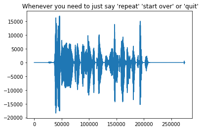

```python
# lets plot the waveform of the clip
def plot_wav(filename):
    spf = wave.open(filename)
    signal = spf.readframes(-1)
    signal = np.fromstring(signal, "int16")

    if spf.getnchannels() == 2:
        print("only mono files allowed")

    plt.figure(1)
    plt.title(s1['Transcription'].iloc[0])
    plt.plot(signal)
    plt.show()

plot_wav(WAV+s1['Filename'].iloc[0]+'.wav')
```

As we can see there is quite a lot of silence at the beginning and end of the clip. This needs to be removed in order to perform further analysis, e.g. for regarding articulation rate.

But we have one big problem. Loading the clips with librosa is quite slow:

```python
import time
import contextlib

def load_file_get_duration_librosa(fn):
    clip, sr = librosa.load(fn)
    d = librosa.get_duration(clip)
    return clip, sr, d


def load_file_get_duration_wave(fn):
    with contextlib.closing(wave.open(fn,'r')) as f:
        frames = f.getnframes()
        rate = f.getframerate()
        duration = frames / float(rate)
    return duration



start_l = time.time()
clip, sr, d = load_file_get_duration_librosa(WAV + s1["Filename"].iloc[0] + ".wav")
end_l = time.time()
print(f"Loading with librosa took {end_l - start_l}s, clip duration: {d}")

start_w = time.time()
d = load_file_get_duration_wave(WAV + s1["Filename"].iloc[0] + ".wav")
end_w = time.time()
print(f"Loading with Wave took {end_w - start_w}s, clip duration: {d}")
```

```
Loading with librosa took 0.6976974010467529s, clip duration: 5.717369614512472
Loading with Wave took 0.00047206878662109375s, clip duration: 5.717333333333333
```

Loading with wave is 1000x faster! Thus we will only use librosa when absolutely necessary.

Let's now have a deeper look at the data. We want to investigate average clip lengths, number of characters, and number of tokens for each clip in order to perform some statistics.

```python
# dictionary to store the abbreviations for the dialects used in the file naming convention
dia_dic = {"no":"Northern English",
           "we": "Welsh English",
           "sc": "Scottish English",
           "so": "Southern English"}


if not os.path.isfile("stat_index.csv"):
    columns = ['LineID', 'Filename', 'Transcription', 'Sex', 'Dialect', 'Duration', 'Tokens', 'Characters']
    index = list(range(len(line_index_df)))
    stat_df = pd.DataFrame(index=index, columns=columns)

    for i, row in tqdm(line_index_df.iterrows(), total=line_index_df.shape[0]):

        # calculate duration for each clip
        try:
            stat_df.iloc[i].Duration = load_file_get_duration_wave(WAV + row.Filename + ".wav")
        except Exception as e:
            print(i)
            print(e)
        # stat_df.Duration[i] = loadload_file_get_duration_librosa(WAV + row.Filename + ".wav")

        # retrieve transcription and remove space from beginning and end
        trans = row.Transcription.strip()

        stat_df.iloc[i].Transcription = trans

        # determine number of characters
        stat_df.iloc[i].Characters = len(trans.strip(" "))

        # determine number of tokens
        stat_df.iloc[i].Tokens = len(re.findall(r"\w+", trans))

        # save all values to new dataframe
        stat_df.iloc[i].LineID = row.LineID
        stat_df.iloc[i].Filename = row.Filename
        # classify whether male or female
        stat_df.iloc[i].Sex = row.Filename[2]
        # Determine the dialect from the filename
        stat_df.iloc[i].Dialect = dia_dic[row.Filename[:2]]


    stat_df.to_csv("stat_index.csv", index=False)
else:
    stat_df = pd.read_csv("stat_index.csv")
```

```python
stat_df.describe()
```

|  | Duration | Tokens | Characters |
| --- | --- | --- | --- |
| count | 16731.000000 | 16731.000000 | 16731.000000 |
| mean | 6.319711 | 13.860200 | 79.006694 |
| std | 2.249960 | 5.368545 | 32.010196 |
| min | 1.621333 | 2.000000 | 9.000000 |
| 25% | 4.693333 | 10.000000 | 56.000000 |
| 50% | 5.973333 | 13.000000 | 77.000000 |
| 75% | 7.680000 | 18.000000 | 100.000000 |
| max | 20.138667 | 29.000000 | 176.000000 |

```python
so_df = stat_df[stat_df.Dialect == dia_dic["so"]]
no_df = stat_df[stat_df.Dialect == dia_dic["no"]]
we_df = stat_df[stat_df.Dialect == dia_dic["we"]]
sc_df = stat_df[stat_df.Dialect == dia_dic["sc"]]
```

```python
print("Southern English")
print(so_df[['Duration', 'Tokens', 'Characters']].describe())
print("\nStandard Deviation:")
print(so_df[['Duration', 'Tokens', 'Characters']].std())
print("\nVariance:")
print(so_df[['Duration', 'Tokens', 'Characters']].var())
```

```
Southern English
          Duration       Tokens   Characters
count  8492.000000  8492.000000  8492.000000
mean      6.190113    13.994936    79.786387
std       2.123131     5.321163    31.708851
min       1.621333     2.000000     9.000000
25%       4.608000    10.000000    57.000000
50%       5.888000    13.000000    77.000000
75%       7.509333    18.000000   100.000000
max      16.469333    29.000000   176.000000

Standard Deviation:
Duration       2.123131
Tokens         5.321163
Characters    31.708851
dtype: float64

Variance:
Duration         4.507686
Tokens          28.314778
Characters    1005.451243
dtype: float64
```

```python
print("Scottish English:")
print(sc_df[['Duration', 'Tokens', 'Characters']].describe())
print("\nStandard Deviation:")
print(sc_df[['Duration', 'Tokens', 'Characters']].std())
print("\nVariance:")
print(sc_df[['Duration', 'Tokens', 'Characters']].var())
```

```
Scottish English:
          Duration       Tokens   Characters
count  2543.000000  2543.000000  2543.000000
mean      6.129672    13.695242    77.929217
std       2.130057     5.468126    32.197679
min       1.621333     2.000000     9.000000
25%       4.522667     9.000000    54.000000
50%       5.802667    13.000000    75.000000
75%       7.509333    18.000000   100.000000
max      13.312000    27.000000   175.000000

Standard Deviation:
Duration       2.130057
Tokens         5.468126
Characters    32.197679
dtype: float64

Variance:
Duration         4.537141
Tokens          29.900398
Characters    1036.690503
dtype: float64
```

```python
print("Northern English:")
print(no_df[['Duration', 'Tokens', 'Characters']].describe())
print("\nStandard Deviation:")
print(no_df[['Duration', 'Tokens', 'Characters']].std())
print("\nVariance:")
print(no_df[['Duration', 'Tokens', 'Characters']].var())
```

```
Northern English:
          Duration       Tokens   Characters
count  2847.000000  2847.000000  2847.000000
mean      6.320571    13.829294    78.812785
std       2.211921     5.292732    31.797835
min       1.621333     2.000000     9.000000
25%       4.693333    10.000000    56.000000
50%       5.973333    13.000000    75.000000
75%       7.594667    18.000000   100.000000
max      14.933333    29.000000   175.000000

Standard Deviation:
Duration       2.211921
Tokens         5.292732
Characters    31.797835
dtype: float64

Variance:
Duration         4.892596
Tokens          28.013014
Characters    1011.102324
dtype: float64
```

```python
print("Welsh English:")
print(we_df[['Duration', 'Tokens', 'Characters']].describe())
print("\nStandard Deviation:")
print(we_df[['Duration', 'Tokens', 'Characters']].std())
print("\nVariance:")
print(we_df[['Duration', 'Tokens', 'Characters']].var())
```

```
Welsh English:
          Duration       Tokens   Characters
count  2849.000000  2849.000000  2849.000000
mean      6.874770    13.636715    77.838189
std       2.639899     5.484241    32.886511
min       1.792000     2.000000     9.000000
25%       4.949333     9.000000    54.000000
50%       6.485333    13.000000    76.000000
75%       8.362667    18.000000    99.000000
max      20.138667    28.000000   175.000000

Standard Deviation:
Duration       2.639899
Tokens         5.484241
Characters    32.886511
dtype: float64

Variance:
Duration         6.969067
Tokens          30.076896
Characters    1081.522614
dtype: float64
```

In metrics that are determined solely from the transcriptions, i.e. number of tokens and number of characters, we can see that the standard deviation and variance is quite similar across the four dialects. When regarding the duration of the recordings however, we can see differences in standard deviation and variance quite clearly. Welsh English has the highest variance in recording duration with 6.97 and also the highest standard deviation with 2.64.

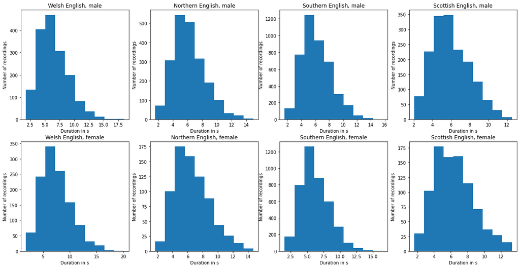

```python
plt.rcParams['figure.figsize'] = [20, 10]
fig, axs = plt.subplots(2,4)
axs[0,0].hist(we_df[we_df['Sex'] == 'm'].Duration.values)
axs[0,0].set_title("Welsh English, male")
axs[1,0].hist(we_df[we_df['Sex'] == 'f'].Duration.values)
axs[1,0].set_title("Welsh English, female")

axs[0,1].hist(no_df[no_df['Sex'] == 'm'].Duration.values)
axs[0,1].set_title("Northern English, male")
axs[1,1].hist(no_df[no_df['Sex'] == 'f'].Duration.values)
axs[1,1].set_title("Northern English, female")

axs[0,2].hist(so_df[so_df['Sex'] == 'm'].Duration.values)
axs[0,2].set_title("Southern English, male")
axs[1,2].hist(so_df[so_df['Sex'] == 'f'].Duration.values)
axs[1,2].set_title("Southern English, female")

axs[0,3].set_title("Scottish English, male")
axs[0,3].hist(sc_df[sc_df['Sex'] == 'm'].Duration.values)
axs[1,3].hist(sc_df[sc_df['Sex'] == 'f'].Duration.values)
axs[1,3].set_title("Scottish English, female")



for ax in axs.flat:
    ax.set(xlabel='Duration in s', ylabel='Number of recordings')
```

```python
%matplotlib inline
```

# Audio Preprocessing

```python
clip, sr = librosa.load(WAV+s1['Filename'].iloc[0].strip(" ")+'.wav')
```

```python
clip_t, index = librosa.effects.trim(clip, top_db=20, frame_length=256, hop_length=64)
```

```python
print(librosa.get_duration(clip), librosa.get_duration(clip_t))
```

```
5.717369614512472 3.4917006802721087
```

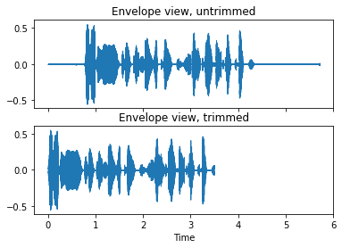

```python
def plot_wave_raw_trim(clip, clip_t, sr):
    fig, ax = plt.subplots(nrows=2, sharex=True)

    librosa.display.waveshow(clip, sr=sr, ax=ax[0])
    ax[0].set(title='Envelope view, untrimmed')
    ax[0].label_outer()
    librosa.display.waveshow(clip_t, sr=sr, ax=ax[1])
    ax[1].set(title='Envelope view, trimmed')
    ax[1].label_outer()

plot_wave_raw_trim(clip, clip_t, sr)
```

```python
def write_clip_to_file_and_play(clip, sr, fn):
    sf.write(fn, clip, sr)
    return IPython.display.Audio(fn)
```

```python
write_clip_to_file_and_play(clip, sr, "/tmp/clip.wav")
```

[interactive chart not shown]

```python
write_clip_to_file_and_play(clip_t, sr, "/tmp/clip.wav")
```

[interactive chart not shown]

As we can hear, the function successfully trims silence at beginning and end of the recording. To visualize this, we can utilize a mel-frequency spectrogram which is a representation of the short-term power spectrum of the recording, based on a linear cosine transform of a log power spectrum on a nonlinear mel scale of frequency [(1)](https://en.wikipedia.org/wiki/Mel-frequency_cepstrum):

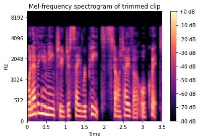

```python
def plot_mel_spec(clip, sr, title='Mel-frequency spectrogram'):
    fig, ax = plt.subplots()

    S = librosa.feature.melspectrogram(y=clip,
                                       sr=sr,
                                       n_mels=128,
                                       fmax=20000)

    S_dB = librosa.power_to_db(S, ref=np.max)

    img = librosa.display.specshow(S_dB,
                                   x_axis='time',
                                   y_axis='mel',
                                   sr=sr,
                                   fmax=10000,
                                   ax=ax)

    fig.colorbar(img, ax=ax, format='%+2.0f dB')
    ax.set(title=title)

plot_mel_spec(clip_t, sr, title='Mel-frequency spectrogram of trimmed clip')
```

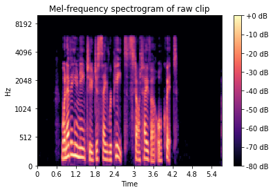

```python
plot_mel_spec(clip, sr, title='Mel-frequency spectrogram of raw clip')
```

But in order to calculate the articulation rate of a given clip we also need the number of syllables of that clip and the clip duration as the articulation rate is defined as follows: $$\text{Articulation Rate} = \frac{\text{# of Syllables}}{\text{Utterance Duration}}$$

```python
# calculate syllables in a given word
def syllable_count(word):
    word = word.lower()
    count = 0
    vowels = "aeiouy"
    if word[0] in vowels:
        count += 1
    for index in range(1, len(word)):
        if word[index] in vowels and word[index - 1] not in vowels:
            count += 1
    if word.endswith("e"):
        count -= 1
    if count == 0:
        count += 1
    return count

# calculate the articulation rate
def articulation_rate(clip, transcription):
    sylls = sum([syllable_count(word) for word in transcription.split(" ")])
    # articulation rate = # of syllables / sentence duration
    return sylls / librosa.get_duration(clip)

articulation_rate(clip_t, s1.Transcription.iloc[0].strip())
```

```
4.295900872817955
```

Now we want to trim every clip in the dataset and determine its trimmed duration and the resulting articulation rate. Unfortunately, we now have to use the slow librosa.load() function in order to use it with librosa.trim(), hence we write the trimmed .wav files to disk, such that we only have to perform this time-consuming task once.

```python
if not os.path.isfile("trim_index.csv"):
    columns = ['LineID', 'Filename', 'Transcription', 'Sex', 'Dialect', 'Articulation Rate', 'Duration', 'Tokens', 'Characters']
    index = list(range(len(stat_df)))
    df = pd.DataFrame(index=index, columns=columns)

    for i, row in tqdm(stat_df.iterrows(), total=stat_df.shape[0]):

        # check if trimmed version exists on disk
        if os.path.isfile(WAV_TRIM + row.Filename + "_trim.wav"):
            # load trimmed version of clip
            clip_t, sr = librosa.load(WAV_TRIM + row.Filename + "_trim.wav")
        # if it doesnt exist, load the raw clip and trim it, then save the trimmed clip
        else:
            # load clip
            clip, sr = librosa.load(WAV+ row.Filename +'.wav')
            # trim clip
            clip_t, index = librosa.effects.trim(clip, top_db=20, frame_length=256, hop_length=64)
            #save the trimmed clip to speed up later processing
            sf.write(WAV_TRIM + row.Filename + "_trim.wav", clip_t, sr)

        # retrieve transcription
        trans = row.Transcription.strip()

        # calculate articulation rate
        ar = articulation_rate(clip_t, trans)

        # for the sake of completeness, also save all relevant values from old dataframe to new dataframe
        df.LineID[i] = row.LineID
        df.Filename[i] = row.Filename
        df.Transcription[i] = row.Transcription
        df.Duration[i] = librosa.get_duration(clip_t)
        df.Tokens[i] = row.Tokens
        df.Characters[i] = row.Characters

        # save articulation rate
        df["Articulation Rate"][i] = ar
        # classify whether male or female
        df.Sex[i] = row.Sex
        # Determine the dialect from the filename
        df.Dialect[i] = row.Dialect
    df.to_csv("trim_index.csv", index=False)
else:
    df = pd.read_csv("trim_index.csv")
```

```python
df.head()
```

|  | LineID | Filename | Transcription | Sex | Dialect | Articulation Rate | Duration | Tokens | Characters |
| --- | --- | --- | --- | --- | --- | --- | --- | --- | --- |
| 0 | EN1223 | wef_12484_01482829612 | The sun provides energy | f | Welsh English | 5.415029 | 1.477370 | 4 | 23 |
| 1 | BI0113 | wef_12484_01345932698 | Zoe invited you to an event | f | Welsh English | 5.273438 | 1.706667 | 6 | 27 |
| 2 | EN0971 | wef_12484_00999757777 | This is the cinematic superhero showdown you'v... | f | Welsh English | 3.896484 | 4.876190 | 12 | 73 |
| 3 | EN0026 | wef_12484_00036278823 | That quick beige fox jumped in the air over ea... | f | Welsh English | 3.241557 | 4.318912 | 12 | 57 |
| 4 | EN1472 | wef_12484_00458512623 | The song was accompanied by two music videos w... | f | Welsh English | 4.135814 | 5.561179 | 14 | 82 |

### Analysis of trimmed recordings

As we now have automatically trimmed the recordings, saved them to disk for quicker access, and determined the articulation rate for each of them, we now want to perform similar statistics to the ones performed for the raw recordings but with an emphasis on utterance duration and articulation rate as other have stayed the same.

```python
# lets first look at the whole dataframe

df.describe()
```

|  | Articulation Rate | Duration | Tokens | Characters |
| --- | --- | --- | --- | --- |
| count | 16731.000000 | 16731.000000 | 16731.000000 | 16731.000000 |
| mean | 4.980209 | 4.421840 | 13.860200 | 79.006694 |
| std | 0.923262 | 2.086447 | 5.368545 | 32.010196 |
| min | 1.287967 | 0.336689 | 2.000000 | 9.000000 |
| 25% | 4.370375 | 2.876372 | 10.000000 | 56.000000 |
| 50% | 4.957730 | 4.069297 | 13.000000 | 77.000000 |
| 75% | 5.564435 | 5.683084 | 18.000000 | 100.000000 |
| max | 16.406250 | 16.303311 | 29.000000 | 176.000000 |

```python
dia_dic
```

```
{'no': 'Northern English',
 'we': 'Welsh English',
 'sc': 'Scottish English',
 'so': 'Southern English'}
```

```python
# now we look at individual groups
we_df = df[df.Dialect == "Welsh English"]
no_df = df[df.Dialect == "Northern English"]
sc_df = df[df.Dialect == "Scottish English"]
so_df = df[df.Dialect == "Southern English"]
```

Since the number of tokens and the number of characters has not changed, we only look at articulation rate and duration:

```python
print("Southern English:")
print(so_df[['Duration', 'Articulation Rate']].describe())
print("\nVariance:")
print(so_df[['Duration', 'Articulation Rate']].var())
```

```
Southern English:
          Duration  Articulation Rate
count  8492.000000        8492.000000
mean      4.344987           5.074572
std       1.980208           0.869819
min       0.589206           1.287967
25%       2.879274           4.524801
50%       4.017052           5.047603
75%       5.558277           5.612183
max      13.754921          10.055444

Variance:
Duration             3.921223
Articulation Rate    0.756585
dtype: float64
```

```python
print("Northern English:")
print(no_df[['Duration', 'Articulation Rate']].describe())
print("\nVariance:")
print(no_df[['Duration', 'Articulation Rate']].var())
```

```
Northern English:
          Duration  Articulation Rate
count  2847.000000        2847.000000
mean      4.232391           5.215656
std       2.043330           0.974759
min       0.574694           2.296875
25%       2.745760           4.542057
50%       3.819683           5.191851
75%       5.442177           5.870730
max      12.863855           8.801893

Variance:
Duration             4.175195
Articulation Rate    0.950155
dtype: float64
```

```python
print("Scottish English:")
print(sc_df[['Duration', 'Articulation Rate']].describe())
print("\nVariance:")
print(sc_df[['Duration', 'Articulation Rate']].var())
```

```
Scottish English:
          Duration  Articulation Rate
count  2543.000000        2543.000000
mean      4.278529           5.075115
std       1.993601           0.887617
min       0.336689           2.528007
25%       2.732698           4.495031
50%       3.979320           5.050132
75%       5.574240           5.613104
max      11.781224          16.406250

Variance:
Duration             3.974445
Articulation Rate    0.787863
dtype: float64
```

```python
print("Welsh English:")
print(we_df[['Duration', 'Articulation Rate']].describe())
print("\nVariance:")
print(we_df[['Duration', 'Articulation Rate']].var())
```

```
Welsh English:
          Duration  Articulation Rate
count  2849.000000        2849.000000
mean      4.968152           4.378948
std       2.406570           0.804549
min       0.635646           1.628989
25%       3.195646           3.832992
50%       4.574331           4.369665
75%       6.455147           4.914075
max      16.303311           7.015342

Variance:
Duration             5.791577
Articulation Rate    0.647299
dtype: float64
```

Interestingly, for the trimmed clips Welsh English still has the highest variance in utterance duration with 5.79 but has the lowest variance in articulation rate with 0.65. Welsh English also hast the largest mean utterance duration with 4.97s and thus also the lowest mean articulation rate with 4.38. Furthermore, Welsh English also has the longest clip duration with 16.30s.

Northern English has the lowest mean utterance duration with 4.23s and the highest mean articulation rate 5.21.

### **ANOVA**

To asses whether the articulation rate differs significantly between the groups, we perform an analysis of variance (ANOVA).

```python
no_ar = np.random.choice(no_df["Articulation Rate"].values, 2543, replace=False)
we_ar = np.random.choice(we_df["Articulation Rate"].values, 2543, replace=False)
so_ar = np.random.choice(so_df["Articulation Rate"].values, 2543, replace=False)
sc_ar = np.random.choice(sc_df["Articulation Rate"].values, 2543, replace=False)
```

```python
import scipy.stats as stats

stats.f_oneway(no_ar, we_ar, so_ar, sc_ar)
```

```
F_onewayResult(statistic=466.5039844545813, pvalue=5.257748994679656e-284)
```

To evalute the effect of gender, we perform an anaylsis of variance on each group.

```python
# lets test if there are significant differences between genders

# split male
no_m_df = no_df[no_df.Sex == "m"]
# split female
no_f_df = no_df[no_df.Sex == "f"]
print("Northern English:\n")
print("Mean Articulation Rate Male:", no_m_df["Articulation Rate"].mean())
print("Mean Articulation Rate Female:", no_f_df["Articulation Rate"].mean())

print(len(no_m_df), len( no_f_df))
stats.f_oneway(np.random.choice(no_m_df["Articulation Rate"].values, len(no_f_df)), no_f_df["Articulation Rate"].values)
```

```
Northern English:

Mean Articulation Rate Male: 5.355744094178813
Mean Articulation Rate Female: 4.823971367783072
2097 750
```

```
F_onewayResult(statistic=109.05269932469953, pvalue=1.0869456661418584e-24)
```

We can see that male Northern English speakers produce significantly [F=109.05, p<0.001] more syllables per second than female speakers of the same dialect group.

```python
# split male
we_m_df = we_df[we_df.Sex == "m"]
# split female
we_f_df = we_df[we_df.Sex == "f"]
print("Welsh English: \n")
print("Mean Articulation Rate Male:", we_m_df["Articulation Rate"].mean())
print("Mean Articulation Rate Female:", we_f_df["Articulation Rate"].mean())

print(len(we_m_df), len( we_f_df))
stats.f_oneway(np.random.choice(we_m_df["Articulation Rate"].values, len(we_f_df)), we_f_df["Articulation Rate"].values)
```

```
Welsh English:

Mean Articulation Rate Male: 4.499540892571599
Mean Articulation Rate Female: 4.212994925767943
1650 1199
```

```
F_onewayResult(statistic=71.87039688004919, pvalue=3.955721418533084e-17)
```

Male Welsh English speakers also produce significantly [F=71.87, p<0.001] more syllables per second than female speakers of the same dialect group.

```python
# split male
so_m_df = so_df[so_df.Sex == "m"]
# split female
so_f_df = so_df[so_df.Sex == "f"]

print("Southern English: \n")
print("Mean Articulation Rate Male:", so_m_df["Articulation Rate"].mean())
print("Mean Articulation Rate Female:", so_f_df["Articulation Rate"].mean())


print(len(so_m_df), len(so_f_df))
stats.f_oneway(np.random.choice(so_f_df["Articulation Rate"].values, len(so_m_df)), so_m_df["Articulation Rate"].values)
```

```
Southern English:

Mean Articulation Rate Male: 5.180759581636182
Mean Articulation Rate Female: 4.964047001609901
4331 4161
```

```
F_onewayResult(statistic=132.18121116922183, pvalue=2.267092950979181e-30)
```

```python
# split male
sc_m_df = sc_df[sc_df.Sex == "m"]
# split female
sc_f_df = sc_df[sc_df.Sex == "f"]

print("Scottish English: \n")
print("Mean Articulation Rate Male:", sc_m_df["Articulation Rate"].mean())
print("Mean Articulation Rate Female:", sc_f_df["Articulation Rate"].mean())

print(len(sc_m_df), len( sc_f_df))
stats.f_oneway(np.random.choice(sc_m_df["Articulation Rate"].values, len(sc_f_df)), sc_f_df["Articulation Rate"].values)
```

```
Scottish English:

Mean Articulation Rate Male: 5.1736352131883026
Mean Articulation Rate Female: 4.893393091146452
1649 894
```

```
F_onewayResult(statistic=56.634863607185466, pvalue=8.272295171192262e-14)
```

Finally, we can see that male Scottish English speakers produce significantly [F=56.63, p<0.001] more syllables per second than female speakers of the same dialect group.

Concluding we can say that we can observe a significant difference in articulation rate between the different dialect groups. Northern English speakers read faster than Southern and Scottish English speakers while Welsh English speakers read the slowest. Differences as a function of sex were also observable as males generally produce more syllables per seconds than females across all dialect groups.

As most volunteers were employees of Google, similar reading capabilities can be assumed. However, as the number of recordings per dialect group greatly differ, it is to be expected that a more evenly spread out dataset would provide more insightful results. Additionally, not all script lines were present in all dialects, skewing the comparison a fair bit.

# Classification

We now want to classify a dialect given the articulation rate, number of tokens, number of characters, and sex of a recorded utterance. A good first step is to use a support vector machine classifier:

```python
# split the data into training and test sets
x_train, x_test, y_train, y_test = train_test_split(df[["Articulation Rate", "Tokens", "Characters", "Sex"]], df["Dialect"]) # passing a dataframe also yields the indices
```

```python
# transform labels into integers
label_dic = {"Northern English": 0,
             "Welsh English":    1,
             "Scottish English": 2,
             "Southern English": 3}
y_train = y_train.apply(lambda x: label_dic[x])
y_test = y_test.apply(lambda x: label_dic[x])

# transform Sexes into categories

sex_dic = {"f": 0, "m": 1}

x_train["Sex"] = x_train["Sex"].apply(lambda x: sex_dic[x])
x_test["Sex"] = x_test["Sex"].apply(lambda x: sex_dic[x])
```

```python
from sklearn.pipeline import make_pipeline
from sklearn.preprocessing import StandardScaler
from sklearn.svm import SVC

clf = make_pipeline(StandardScaler(), SVC(gamma='auto'))

clf.fit(x_train, y_train)
```

```
Pipeline(steps=[('standardscaler', StandardScaler()),
                ('svc', SVC(gamma='auto'))])
```

```python
# compute the accuracy across the test set
clf.score(x_test, y_test)
```

```
0.5190054984460913
```

Using a vanilla support vector machine classifier we get an accurcay of about 50% which is above chance for the four classes.

We now use grid search and cross validation to see if we can find better hyperparameters than the defaults.

```python
from sklearn.model_selection import cross_val_score, GridSearchCV
from sklearn.pipeline import Pipeline

clf = Pipeline([('scaler', StandardScaler()), ('svc', SVC(random_state=420))])

params = {'svc__C': [10, 100, 1000], 'svc__gamma': [0.001, 0.0001], 'svc__kernel': ['poly', 'sigmoid', 'rbf']}

gs = GridSearchCV(clf, params, n_jobs=-1)
gs.fit(x_train, y_train)
```

```
GridSearchCV(estimator=Pipeline(steps=[('scaler', StandardScaler()),
                                       ('svc', SVC(random_state=420))]),
             n_jobs=-1,
             param_grid={'svc__C': [10, 100, 1000],
                         'svc__gamma': [0.001, 0.0001],
                         'svc__kernel': ['poly', 'sigmoid', 'rbf']})
```

```python
# choose the best performing estimator and test it on the test set
gs.best_estimator_.score(x_test, y_test)
```

```
0.513746115228305
```

```python
# let's save the best estimator for quicker loading times
pickle.dump(gs.best_estimator_, open("svc_best_gridsearchCV.p", "wb"))
```

As we can see, even after performing a crosss validated grid search the support vector classifier still only just beats 50% accuracy.

Let's now fit a simple multi-layer perceptrion to the data:

```python
from tensorflow.keras import models, layers

model = models.Sequential()
model.add(layers.Input(shape=(4)))
model.add(layers.Dense(32))
model.add(layers.Dropout(0.5))
model.add(layers.Dense(128))
model.add(layers.Dropout(0.5))
model.add(layers.Dense(64))
model.add(layers.Dropout(0.5))
model.add(layers.Dense(32))
model.add(layers.Dense(4, activation="softmax"))

model.summary()
```

```
Model: "sequential_15"
_________________________________________________________________
Layer (type)                 Output Shape              Param #
=================================================================
dense_71 (Dense)             (None, 32)                160
_________________________________________________________________
dropout_48 (Dropout)         (None, 32)                0
_________________________________________________________________
dense_72 (Dense)             (None, 128)               4224
_________________________________________________________________
dropout_49 (Dropout)         (None, 128)               0
_________________________________________________________________
dense_73 (Dense)             (None, 64)                8256
_________________________________________________________________
dropout_50 (Dropout)         (None, 64)                0
_________________________________________________________________
dense_74 (Dense)             (None, 32)                2080
_________________________________________________________________
dense_75 (Dense)             (None, 4)                 132
=================================================================
Total params: 14,852
Trainable params: 14,852
Non-trainable params: 0
_________________________________________________________________
```

```python
model.compile(loss="categorical_crossentropy", optimizer="adam", metrics=["accuracy"])
```

```python
# since the mlp requires categorical labels, we have to transform them
y_train = tf.keras.utils.to_categorical(y_train.values, 4)
y_test = tf.keras.utils.to_categorical(y_test.values, 4)
```

```python
model.fit(x=x_train, y=y_train, batch_size=32, epochs=20)
```

```
<keras.callbacks.History at 0x7fb58954d310>
```

```python
model.evaluate(x_test.values, y_test)
```

```
[1.2001237869262695, 0.5137461423873901]
```

[1] https://arxiv.org/abs/1611.03530

[2] https://arxiv.org/abs/1710.10686

```python
model = models.Sequential()
model.add(layers.Input(shape=(4)))
model.add(layers.Dense(64))
model.add(layers.Activation('tanh'))
model.add(layers.Dropout(0.5))
model.add(layers.Dense(256))
model.add(layers.Activation('tanh'))
model.add(layers.Dropout(0.5))
model.add(layers.Dense(512))
model.add(layers.Activation('tanh'))
model.add(layers.Dropout(0.5))
model.add(layers.Dense(512))
model.add(layers.Activation('tanh'))
model.add(layers.Dropout(0.5))
model.add(layers.Dense(256))
model.add(layers.Activation('tanh'))
model.add(layers.Dropout(0.5))
model.add(layers.Dense(64))
model.add(layers.Activation('tanh'))
model.add(layers.Dropout(0.5))
model.add(layers.Dense(4, activation="softmax"))

model.summary()
```

```
Model: "sequential_16"
_________________________________________________________________
Layer (type)                 Output Shape              Param #
=================================================================
dense_76 (Dense)             (None, 64)                320
_________________________________________________________________
activation_26 (Activation)   (None, 64)                0
_________________________________________________________________
dropout_51 (Dropout)         (None, 64)                0
_________________________________________________________________
dense_77 (Dense)             (None, 256)               16640
_________________________________________________________________
activation_27 (Activation)   (None, 256)               0
_________________________________________________________________
dropout_52 (Dropout)         (None, 256)               0
_________________________________________________________________
dense_78 (Dense)             (None, 512)               131584
_________________________________________________________________
activation_28 (Activation)   (None, 512)               0
_________________________________________________________________
dropout_53 (Dropout)         (None, 512)               0
_________________________________________________________________
dense_79 (Dense)             (None, 512)               262656
_________________________________________________________________
activation_29 (Activation)   (None, 512)               0
_________________________________________________________________
dropout_54 (Dropout)         (None, 512)               0
_________________________________________________________________
dense_80 (Dense)             (None, 256)               131328
_________________________________________________________________
activation_30 (Activation)   (None, 256)               0
_________________________________________________________________
dropout_55 (Dropout)         (None, 256)               0
_________________________________________________________________
dense_81 (Dense)             (None, 64)                16448
_________________________________________________________________
activation_31 (Activation)   (None, 64)                0
_________________________________________________________________
dropout_56 (Dropout)         (None, 64)                0
_________________________________________________________________
dense_82 (Dense)             (None, 4)                 260
=================================================================
Total params: 559,236
Trainable params: 559,236
Non-trainable params: 0
_________________________________________________________________
```

```python
model.compile(loss="categorical_crossentropy", optimizer="adam", metrics=["accuracy"])
```

```python
model.fit(x=x_train, y=y_train, batch_size=32, epochs=20)
```

```
<keras.callbacks.History at 0x7fb5897620d0>
```

However, as we do not have the same number of total recordings, not the same number of male and female recordings, and not the same lines for each dialect, this could be an influencing factor.

# **Conclusion**

In this Jupyter Notebook we examined the "Open-source Multi-speaker Corpora of the English Accents in the British Isles". The provided data are recorded audio clips where participants of six major dialect groups of the British Isles read selected lines from a curated script. Four out of six of these dialect groups were selected and analysed.

After gaining insight on the structure of the data, we determined metrics, i.e. recording duration, number of tokens, and number of characters for each of them. Next we automatically trimmed the recordings to exclude silence at the beginning and end of each clip in order to calculate the articulation rate. Articulation rate is a valuable metric to investigate speech tempo as it allows all speakers of a given dataset to produce the same sample.

Statistical analysis of the data has shown that the articulation rate significantly differs between the dialect groups. Within dialect groups, the articualtion rate is also significantly different between the sexes.

But as the dataset does not provide the same number of recordings for each dialect and gender results may be skewed. Furthermore, not every speaker spoke every line in the script and not every line is present in each dialect group and sex which may also influence analysis. Age of the speaker was also not recorded by the curators of the dataset which could provide helpful clues in the investigation. However, since the speakers were mostly employees of Google, individual differences due to varying education levels are to be neglected.

### **Additional Material**

However, the melspectrogram contains vastly more information than the four simple features that were used earlier and thus it is to be expected that the resulting classification will also yield much higher accuraces.

```python
# train test split
x_train, x_test, y_train, y_test = train_test_split(df["Filename"], df["Dialect"]) # passing a dataframe also yields the indices
```

```python
label_dic = {"Northern English": 0,
             "Welsh English":    1,
             "Scottish English": 2,
             "Southern English": 3}

# generator that returns a batch of melspectrograms and their associated labels
def data_gen(X, y, batch_size=5):

    for i in range(len(X) - batch_size):
        # read in wave files from filenames
        clips = [librosa.load(WAV_TRIM + fn + "_trim.wav") for fn in X[i:i+batch_size]]

        # generate melspectrograms
        ms = [librosa.feature.melspectrogram(y=c[0], sr=c[1]) for c in clips]

        # up/downscale melspectrograms
        ms_res = [cv2.resize(m, (256,256))[..., np.newaxis] for m in ms]

        # create labels from Dict
        labels = [label_dic[l] for l in y[i:i+batch_size]]

        # yield tuple of features and labels
        yield (np.array(ms_res), np.array(labels)[..., np.newaxis])
```

```python
# model definition
model = models.Sequential()
model.add(layers.Input(shape=(256,256,1)))
model.add(layers.Conv2D(32, kernel_size=(5,5), activation="relu"))
model.add(layers.MaxPooling2D(pool_size=(2,2)))
model.add(layers.Conv2D(32, kernel_size=(5,5), activation="relu"))
model.add(layers.MaxPooling2D(pool_size=(2,2)))
model.add(layers.Flatten())
#model.add(layers.Dropout(0.5))
model.add(layers.Dense(4))

model.summary()
```

```
Model: "sequential_7"
_________________________________________________________________
Layer (type)                 Output Shape              Param #
=================================================================
conv2d_2 (Conv2D)            (None, 252, 252, 32)      832
_________________________________________________________________
max_pooling2d_2 (MaxPooling2 (None, 126, 126, 32)      0
_________________________________________________________________
conv2d_3 (Conv2D)            (None, 122, 122, 32)      25632
_________________________________________________________________
max_pooling2d_3 (MaxPooling2 (None, 61, 61, 32)        0
_________________________________________________________________
flatten_1 (Flatten)          (None, 119072)            0
_________________________________________________________________
dense_35 (Dense)             (None, 4)                 476292
=================================================================
Total params: 502,756
Trainable params: 502,756
Non-trainable params: 0
_________________________________________________________________
```

```python
batch_size = 16
epochs = 10

model.compile(loss="categorical_crossentropy", optimizer="adam", metrics=["accuracy"])
```

```python
# unfortunately, my gpu is too slow to train this model fully
# model.fit(x=data_gen(x_train, y_train, batch_size=batch_size), epochs=1)
```

```python
# model.evaluate(x=data_gen(x_test, y_test, batch_size=batch_size))
```